# Create and analyze Linear Regression Models

INET4061 Lab 4  
Mahsa Ayoughi  
September 29, 2019

# Overview

```python
%matplotlib inline
import matplotlib.pyplot as plt
import pandas as pd
import numpy as np

import scipy.stats as stats
import statsmodels.api as sm
from sklearn import datasets, linear_model
from sklearn.metrics import mean_squared_error, r2_score

np.set_printoptions(linewidth=160)

import seaborn as sns
plt.style.use('seaborn') # pretty matplotlib plots

plt.rc('font', size=14)
plt.rc('figure', titlesize=18)
plt.rc('axes', labelsize=15)
plt.rc('axes', titlesize=18)
```

# Data

From Bradley Efron, Trevor Hastie, Iain Johnstone and Robert Tibshirani (2004) "Least Angle Regression," Annals of Statistics (with discussion), 407-499, we have

"Ten baseline variables, age, sex, body mass index, average blood pressure, and six blood serum measurements were obtained for each of n = 442 diabetes patients, as well as the response of interest, a quantitative measure of disease progression one year after baseline."

In the tab delimited file above, the variables are named

AGE SEX BMI BP S1 S2 S3 S4 S5 S6 Y

```python
diabetes = datasets.load_diabetes()
type(diabetes)
```

```
sklearn.utils.Bunch
```

```python
diabetes.feature_names
```

```
['age', 'sex', 'bmi', 'bp', 's1', 's2', 's3', 's4', 's5', 's6']
```

```python
print(diabetes.DESCR)
```

```
.. _diabetes_dataset:

Diabetes dataset
----------------

Ten baseline variables, age, sex, body mass index, average blood
pressure, and six blood serum measurements were obtained for each of n =
442 diabetes patients, as well as the response of interest, a
quantitative measure of disease progression one year after baseline.

**Data Set Characteristics:**

  :Number of Instances: 442

  :Number of Attributes: First 10 columns are numeric predictive values

  :Target: Column 11 is a quantitative measure of disease progression one year after baseline

  :Attribute Information:
      - Age
      - Sex
      - Body mass index
      - Average blood pressure
      - S1
      - S2
      - S3
      - S4
      - S5
      - S6

Note: Each of these 10 feature variables have been mean centered and scaled by the standard deviation times `n_samples` (i.e. the sum of squares of each column totals 1).

Source URL:
https://www4.stat.ncsu.edu/~boos/var.select/diabetes.html

For more information see:
Bradley Efron, Trevor Hastie, Iain Johnstone and Robert Tibshirani (2004) "Least Angle Regression," Annals of Statistics (with discussion), 407-499.
(https://web.stanford.edu/~hastie/Papers/LARS/LeastAngle_2002.pdf)
```

```python
df = pd.DataFrame(diabetes.data, columns=diabetes.feature_names)
print(df.head()) #We can examine the data set using the pandas’ head() method.
df_X= df
```

```
        age       sex       bmi        bp        s1        s2        s3  \
0  0.038076  0.050680  0.061696  0.021872 -0.044223 -0.034821 -0.043401
1 -0.001882 -0.044642 -0.051474 -0.026328 -0.008449 -0.019163  0.074412
2  0.085299  0.050680  0.044451 -0.005671 -0.045599 -0.034194 -0.032356
3 -0.089063 -0.044642 -0.011595 -0.036656  0.012191  0.024991 -0.036038
4  0.005383 -0.044642 -0.036385  0.021872  0.003935  0.015596  0.008142

         s4        s5        s6
0 -0.002592  0.019908 -0.017646
1 -0.039493 -0.068330 -0.092204
2 -0.002592  0.002864 -0.025930
3  0.034309  0.022692 -0.009362
4 -0.002592 -0.031991 -0.046641
```

# Exploratory data analysis

```python
df.shape #find the dimensions of the data set
```

```
(442, 10)
```

```python
df.isna().sum()
#check for nans
```

```
age    0
sex    0
bmi    0
bp     0
s1     0
s2     0
s3     0
s4     0
s5     0
s6     0
dtype: int64
```

shows that we have no nans

```python
# Summary for numeric independent variables
df.round(4).describe()
```

|  | age | sex | bmi | bp | s1 | s2 | s3 | s4 | s5 | s6 |
| --- | --- | --- | --- | --- | --- | --- | --- | --- | --- | --- |
| count | 442.000000 | 442.000000 | 442.000000 | 442.000000 | 442.000000 | 442.000000 | 442.000000 | 442.000000 | 4.420000e+02 | 442.000000 |
| mean | 0.000001 | 0.000031 | -0.000003 | 0.000001 | 0.000001 | 0.000001 | 0.000002 | -0.000006 | -6.787330e-07 | -0.000003 |
| std | 0.047614 | 0.047608 | 0.047621 | 0.047619 | 0.047616 | 0.047619 | 0.047618 | 0.047618 | 4.761712e-02 | 0.047618 |
| min | -0.107200 | -0.044600 | -0.090300 | -0.112400 | -0.126800 | -0.115600 | -0.102300 | -0.076400 | -1.261000e-01 | -0.137800 |
| 25% | -0.037300 | -0.044600 | -0.034200 | -0.036700 | -0.034250 | -0.030325 | -0.035100 | -0.039500 | -3.320000e-02 | -0.033175 |
| 50% | 0.005400 | -0.044600 | -0.007300 | -0.005700 | -0.004300 | -0.003800 | -0.006600 | -0.002600 | -1.950000e-03 | -0.001100 |
| 75% | 0.038100 | 0.050700 | 0.031225 | 0.035600 | 0.028350 | 0.029850 | 0.029300 | 0.034300 | 3.240000e-02 | 0.027900 |
| max | 0.110700 | 0.050700 | 0.170600 | 0.132000 | 0.153900 | 0.198800 | 0.181200 | 0.185200 | 1.336000e-01 | 0.135600 |

```python
diabetes.target[0:5]
```

```
array([151.,  75., 141., 206., 135.])
```

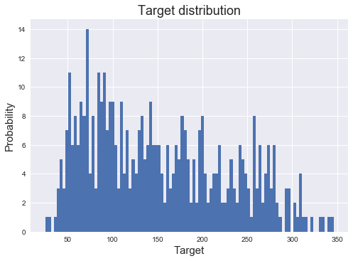

```python
plt.hist(diabetes.target, bins=100)
plt.ylabel('Probability')
plt.xlabel('Target')
plt.title('Target distribution')
```

# Log Function + 1

https://towardsdatascience.com/transforming-skewed-data-73da4c2d0d16

This function is for making data less skewed. When using log with Python, the default base is usually e. Furthermore, the same spread is retained since all points are increased by 1.

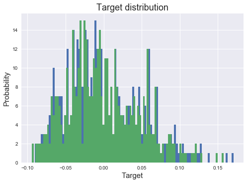

```python
#Log Transformation

X = diabetes.data[:, np.newaxis, 2]

plt.hist(X, bins=100)
plt.ylabel('Probability')
plt.xlabel('Target')
plt.title('Target distribution')

X = diabetes.data[:, np.newaxis, 2]
# + 1 to avoid negative values
X = np.log(X + 1)

plt.hist(X, bins=100)
plt.ylabel('Probability')
plt.xlabel('Target')
plt.title('Target distribution')
```

https://scikit-learn.org/stable/modules/generated/sklearn.preprocessing.quantile_transform.html This method transforms the features to follow a uniform or a normal distribution. Therefore, for a given feature, this transformation tends to spread out the most frequent values. It also reduces the impact of (marginal) outliers: this is therefore a robust preprocessing scheme.

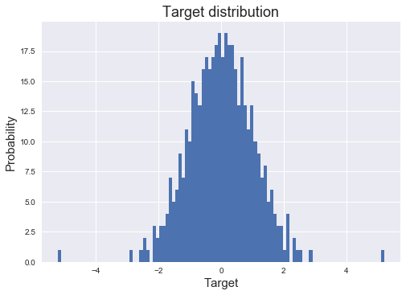

```python
from sklearn.preprocessing import QuantileTransformer, quantile_transform

y = diabetes.target
y = y.squeeze()
y_trans = quantile_transform(y.reshape(-1, 1) ,
                         	n_quantiles=300, #Number of quantiles to be computed
                         	output_distribution='normal', #Marginal distribution for the transformed data
                             copy=True).squeeze() #If True, a copy of X is transformed, leaving the original X unchanged

plt.hist(y_trans, bins=100)
plt.ylabel('Probability')
plt.xlabel('Target')
plt.title('Target distribution')
```

# Model

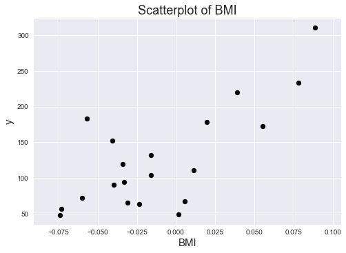

```python
# Use only one feature
diabetes_X = diabetes.data[:, np.newaxis, 2]
diabetes_X_train = diabetes_X[:-20]
diabetes_X_test = diabetes_X[-20:]

# Split the targets into training/testing sets
diabetes_y_train = diabetes.target[:-20]
diabetes_y_test = diabetes.target[-20:]

# Plot outputs
plt.scatter(diabetes_X_test, diabetes_y_test,  color='black')

plt.title('Scatterplot of BMI')
plt.xlabel('BMI')
plt.ylabel('y')

plt.show()
```

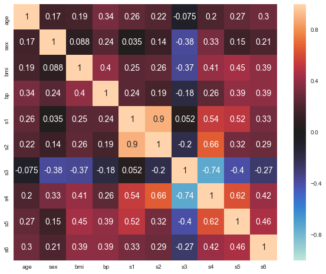

```python
# correlation matrix
fig, ax = plt.subplots(figsize=(10,8))
corrmat = df.corr() # Omit year
sns.heatmap(corrmat,-1,1,ax=ax,center=0,annot=True);
```

this heat map showes the correlations among columns between range -1 to 1. The lighter the color, the larger the correlation magnitude. Negative correlations are in blue color

# Simple linear Regressin (scipy.stats)

Ordinery Least Squares Linear Regressin

```python
import pylab
import scipy.stats as stats
import statsmodels.api as sm

x= diabetes_X_train
x=sm.add_constant(x)
y= diabetes_y_train
ols_lm=sm.OLS(y,x)
ols_fit= ols_lm.fit()
ols_fit.summary()
```

OLS Regression Results

| Dep. Variable: | y | R-squared: | 0.335 |
| --- | --- | --- | --- |
| Model: | OLS | Adj. R-squared: | 0.334 |
| Method: | Least Squares | F-statistic: | 211.7 |
| Date: | Sat, 05 Oct 2019 | Prob (F-statistic): | 3.98e-39 |
| Time: | 22:29:10 | Log-Likelihood: | -2346.5 |
| No. Observations: | 422 | AIC: | 4697. |
| Df Residuals: | 420 | BIC: | 4705. |
| Df Model: | 1 |  |  |
| Covariance Type: | nonrobust |  |  |

|  | coef | std err | t | P>\|t\| | [0.025 | 0.975] |
| --- | --- | --- | --- | --- | --- | --- |
| const | 152.9189 | 3.069 | 49.830 | 0.000 | 146.887 | 158.951 |
| x1 | 938.2379 | 64.484 | 14.550 | 0.000 | 811.487 | 1064.989 |

| Omnibus: | 12.587 | Durbin-Watson: | 1.839 |
| --- | --- | --- | --- |
| Prob(Omnibus): | 0.002 | Jarque-Bera (JB): | 7.334 |
| Skew: | 0.142 | Prob(JB): | 0.0255 |
| Kurtosis: | 2.420 | Cond. No. | 21.0 |

Warnings:  
[1] Standard Errors assume that the covariance matrix of the errors is correctly specified.

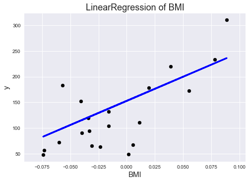

```python
# Create linear regression object
regr = linear_model.LinearRegression()

# Train the model using the training sets
regr.fit(diabetes_X_train, diabetes_y_train)

# Make predictions using the testing set
diabetes_y_pred = regr.predict(diabetes_X_test)
# Plot outputs
plt.scatter(diabetes_X_test, diabetes_y_test,  color='black')
plt.plot(diabetes_X_test, diabetes_y_pred, color='blue', linewidth=3)

plt.title('LinearRegression of BMI')
plt.xlabel('BMI')
plt.ylabel('y')

plt.show()
plt.savefig('graph.png')
```

For regressin algorithms, three avaluation metrics are commonly used:

```
- Mean Absolute Error(MAE) is the mean of the absolute value of the errors
- Mean Squared Error (MSE) is the mean of the squared errors
- Root Mean Squared Error(RMSE) is the square root of the mean of the squared errors
```

MAE = $\frac{1}{n}\sum_{j=1}^n |y_j-\hat y_j|$

MSE = $\frac{1}{n}\sum_{i=1}^n (y_j-\hat y_j)^2$

RMSE = $\sqrt{\frac{1}{n}\sum_{i=1}^n (y_j-\hat y_j)^2}$

```python
# The mean squared error
print("Mean squared error: %.2f"
      % mean_squared_error(diabetes_y_test, diabetes_y_pred))

print("Root mean squared error: %.2f"
      % np.sqrt( mean_squared_error(diabetes_y_test, diabetes_y_pred)) )

print("\nMean of diabetes target variable = ",diabetes_y_test.mean())

print("RMSE percentage of diabetes mean = ", \
      100 * np.sqrt( mean_squared_error(diabetes_y_test, diabetes_y_pred))/diabetes_y_test.mean())
```

```
Mean squared error: 2548.07
Root mean squared error: 50.48

Mean of diabetes target variable =  126.2
RMSE percentage of diabetes mean =  39.99875989452685
```

Root mean squared error is 50.48, which is about 40% of the mean of the test diabetes varible. This means that the simple linear regressin model is not very accurate.

```python
print(regr.intercept_)
```

```
152.91886182616167
```

```python
print(regr.coef_)
```

```
[938.23786125]
```

(y = mx + b)

the intercept is our b in this equation anf the coef is our slope(m):

y = 938.23786125x + 152.91886182616167

I don't belive this is a accepteble model beacuse the mean is not very accurate

# Multiple linear regression model

```python
diabetes_X = diabetes.data

# Split the data into training/testing sets
diabetes_X_train = diabetes_X[:-20]
diabetes_X_test = diabetes_X[-20:]

# Create linear regression object
lm = linear_model.LinearRegression()

# Train the model using the training sets
fit = lm.fit(diabetes_X_train, diabetes_y_train)

# Make predictions using the testing set
diabetes_y_pred = fit.predict(diabetes_X_test)

# The coefficients
print('Coefficients: \n', fit.coef_)
print ( type(fit.coef_))

# https://bigdata-madesimple.com/how-to-run-linear-regression-in-python-scikit-learn/
# get feature names
colnames = np.asarray(df.columns)

# https://pandas.pydata.org/pandas-docs/stable/user_guide/merging.html
df_col = pd.DataFrame( data = np.asarray(df.columns)  )
df_coef = pd.DataFrame( data = fit.coef_)
df_tbl =  pd.concat ( [df_col, df_coef] , axis = 1 )
df_tbl.columns = ['Columns', 'Coefficients']
df_tbl

#  scipy.stats OLS linear regression model
X_train = sm.add_constant(diabetes_X_train)
lm2 = sm.OLS(diabetes_y_train, X_train).fit()
lm2.summary()
```

```
Coefficients:
 [ 3.03499549e-01 -2.37639315e+02  5.10530605e+02  3.27736980e+02 -8.14131709e+02  4.92814588e+02  1.02848452e+02  1.84606489e+02  7.43519617e+02
  7.60951722e+01]
<class 'numpy.ndarray'>
```

OLS Regression Results

| Dep. Variable: | y | R-squared: | 0.512 |
| --- | --- | --- | --- |
| Model: | OLS | Adj. R-squared: | 0.500 |
| Method: | Least Squares | F-statistic: | 43.16 |
| Date: | Sat, 05 Oct 2019 | Prob (F-statistic): | 4.64e-58 |
| Time: | 22:29:10 | Log-Likelihood: | -2281.1 |
| No. Observations: | 422 | AIC: | 4584. |
| Df Residuals: | 411 | BIC: | 4629. |
| Df Model: | 10 |  |  |
| Covariance Type: | nonrobust |  |  |

|  | coef | std err | t | P>\|t\| | [0.025 | 0.975] |
| --- | --- | --- | --- | --- | --- | --- |
| const | 152.7643 | 2.658 | 57.469 | 0.000 | 147.539 | 157.990 |
| x1 | 0.3035 | 61.286 | 0.005 | 0.996 | -120.169 | 120.776 |
| x2 | -237.6393 | 62.837 | -3.782 | 0.000 | -361.162 | -114.117 |
| x3 | 510.5306 | 68.156 | 7.491 | 0.000 | 376.553 | 644.508 |
| x4 | 327.7370 | 66.876 | 4.901 | 0.000 | 196.275 | 459.199 |
| x5 | -814.1317 | 424.044 | -1.920 | 0.056 | -1647.697 | 19.434 |
| x6 | 492.8146 | 344.227 | 1.432 | 0.153 | -183.850 | 1169.480 |
| x7 | 102.8485 | 219.463 | 0.469 | 0.640 | -328.561 | 534.258 |
| x8 | 184.6065 | 167.336 | 1.103 | 0.271 | -144.334 | 513.547 |
| x9 | 743.5196 | 175.359 | 4.240 | 0.000 | 398.807 | 1088.232 |
| x10 | 76.0952 | 68.293 | 1.114 | 0.266 | -58.152 | 210.343 |

| Omnibus: | 1.544 | Durbin-Watson: | 2.026 |
| --- | --- | --- | --- |
| Prob(Omnibus): | 0.462 | Jarque-Bera (JB): | 1.421 |
| Skew: | 0.004 | Prob(JB): | 0.491 |
| Kurtosis: | 2.716 | Cond. No. | 224. |

Warnings:  
[1] Standard Errors assume that the covariance matrix of the errors is correctly specified.

```python
print(lm.intercept_)
```

```
152.76430691633442
```

```python
print(lm.coef_)
```

```
[ 3.03499549e-01 -2.37639315e+02  5.10530605e+02  3.27736980e+02 -8.14131709e+02  4.92814588e+02  1.02848452e+02  1.84606489e+02  7.43519617e+02
  7.60951722e+01]
```

ŷ = b0 + b1x1 + b2x2 + … + bk-1xk-1 + bkxk where b0,b1,b2,...,bk are our Coefficients list:

[ 3.03499549e-01, -2.37639315e+02, 5.10530605e+02, 3.27736980e+02, -8.14131709e+02 4.92814588e+02, 1.02848452e+02, 1.84606489e+02, 7.43519617e+02, 7.60951722e+01]

and y and x are our varibles.

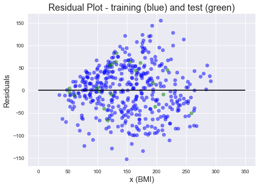

```python
# c = color
# alpha - blending value, between 0 (transparent) and 1 (opaque)
lm = linear_model.LinearRegression()

# Train the model using the training sets
fit = lm.fit(diabetes_X_train, diabetes_y_train)
plt.scatter( fit.predict(diabetes_X_train), fit.predict(diabetes_X_train) - diabetes_y_train, c = 'b', alpha = '0.5')
plt.scatter( fit.predict(diabetes_X_test), fit.predict(diabetes_X_test) - diabetes_y_test, c = 'g', alpha = '0.5')
plt.hlines(y = 0, xmin = 0, xmax = 350)
plt.title('Residual Plot - training (blue) and test (green)')
plt.ylabel('Residuals')
plt.xlabel('x (BMI)')
```

Reseduals are pretty evenly distributed abouth the x-axis, so hetrosedasticly(variability of a varible unequal across the range of values of a second varible that predicts it)and kertosis appears acceptable. Larger distances from x-axis show variability (spread) in the relationship between x and y. Also, points far from the x-axis indicate possible ouliers.

# Outliers

```python
# get the studentized residuals using get_influence( )
influence = lm2.get_influence()
cook = influence.summary_frame().cooks_d
# number of observations with a Cok distance > 1 (influential points)
cook[ cook > 1 ].sum()

resid_student = influence.resid_studentized_external
resid_student[0:5]

# Combine training set and residuals
X_train = pd.DataFrame(data = diabetes_X_train)
resid = pd.concat([X_train,pd.Series(resid_student,name = "Studentized Residuals")],axis = 1)

# If the absolute value of studentized residuals is more than 3
# 	then that observation is considered as an outlier.
# Create a logical vector for the absolute studentized residuals more than 3

resid.loc[np.absolute(resid["Studentized Residuals"]) > 3,:]
```

|  | 0 | 1 | 2 | 3 | 4 | 5 | 6 | 7 | 8 | 9 | Studentized Residuals |
| --- | --- | --- | --- | --- | --- | --- | --- | --- | --- | --- | --- |

No outliers found